# Projet Statistique&R

### Sommaire

1. Lien entre les dépenses dans l’éducation et le taux de chômage chez les jeunes de 15-24 ans
2. Lien entre la croissance de la population et le taux de natalité

### Packages

```r
library(dplyr)
library(ggplot2)
library(shiny)
library(statsr)
```

### Données

```r
wfb = read.csv('wfb2.csv')
dim(wfb)
```

```
## [1] 279  76
```

```r
#names(wfb)
```

### 1. Y a-t-il une corrélation entre les dépenses dans l’éducation et le taux de chômage chez les jeunes de 15-24 ans ?

Pour répondre à la question, nous allons nous intéresser aux données suivantes: -dépenses dans l’éducation pour chaque pays -chômage 15-24 ans pour chaque pays

```r
str(wfb$Education.expenditures)
```

```
##  num [1:279] NA NA 3.3 4.3 NA NA 3.5 2.8 NA 2.4 ...
```

```r
str(wfb$Unemployment..youth.ages.15.24)
```

```
##  num [1:279] NA NA 22.5 22.4 NA NA NA NA NA NA ...
```

Nous allons restreindre l’étude dans les pays où ces deux informations sont renseignées.

```r
wfb_restreint <- wfb %>%
filter(Education.expenditures != "NA",Unemployment..youth.ages.15.24 != "NA")
dim(wfb_restreint)
```

```
## [1] 119  76
```

L’étude se limite à 119 pays

```r
summary(wfb_restreint$Education.expenditures)
```

```
##    Min. 1st Qu.  Median    Mean 3rd Qu.    Max.
##   1.300   3.450   4.900   4.911   5.950  13.000
```

```r
summary(wfb_restreint$Unemployment..youth.ages.15.24)
```

```
##    Min. 1st Qu.  Median    Mean 3rd Qu.    Max.
##    1.30    9.50   17.10   19.00   23.75   55.30
```

### Etude d’une possible corrélation via la régression linéaire

```r
plot(wfb_restreint$Education.expenditures, wfb_restreint$Unemployment..youth.ages.15.24, lwd=0.3, title("Correlation entre les dépenses liées à l'éducation et le taux de chômage chez les 15-24 ans"))

#Calcul des coefficients a et b
xi=wfb_restreint$Education.expenditures
yi=wfb_restreint$Unemployment..youth.ages.15.24
xbar=mean(xi)
ybar=mean(yi)
a = cov(xi,yi)/var(xi)
b = ybar - a*xbar
a
```

```
## [1] 0.4814503
```

```r
b
```

```
## [1] 16.63479
```

```r
#Equation de la droite
y = a*xi+b

#Calcul du coefficient lineaire
RSS=sum((yi-y)^2)
TSS=sum((yi-ybar)^2)

coeff = 1-(RSS/TSS)
coeff
```

```
## [1] 0.00591589
```

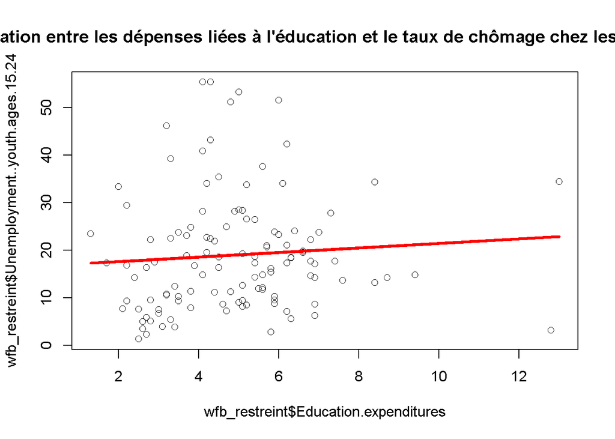

```r
#Graphe
leg=paste("y =",round(a,3),"x +",round(b,3))
lines(y~wfb_restreint$Education.expenditures, type='l',col='red', lwd=3)
legend(10,100,leg,col='red', lty=1:2,cex = 0.8)
```

#### Vérification avec les formules de R

```r
model<-lm(Unemployment..youth.ages.15.24 ~ Education.expenditures, data = wfb)
summary(model)
```

```
##
## Call:
## lm(formula = Unemployment..youth.ages.15.24 ~ Education.expenditures,
##     data = wfb)
##
## Residuals:
##     Min      1Q  Median      3Q     Max
## -19.697  -8.751  -2.209   4.982  36.691
##
## Coefficients:
##                        Estimate Std. Error t value Pr(>|t|)
## (Intercept)             16.6348     3.0458   5.462 2.69e-07 ***
## Education.expenditures   0.4815     0.5770   0.834    0.406
## ---
## Signif. codes:  0 '***' 0.001 '**' 0.01 '*' 0.05 '.' 0.1 ' ' 1
##
## Residual standard error: 12.19 on 117 degrees of freedom
##   (160 observations deleted due to missingness)
## Multiple R-squared:  0.005916,   Adjusted R-squared:  -0.002581
## F-statistic: 0.6963 on 1 and 117 DF,  p-value: 0.4057
```

Nous retrouvons le même coefficient linéaire et les mêmes valeurs pour a et b.

### Conclusion

Nous obtenons un coefficient linéaire très proche de 0 (environ 0,006) : il n’y a pas de relation linéaire entre les deux variables. Nous avions pour hypothèse que, plus les dépenses liées à l’éducation étaient élevées, plus le taux de chômage chez les jeunes de 15-24 ans serait faible. Finalement, cela ne semble pas être le cas. Cela est peut être du au fait qu’il y a plus de paramètres à prendre en compte. Déjà, l’unité des dépenses liées à l’éducation est un pourcentage du PIB. On pourrait penser que certains pays qui ont un PIB plus élevé ont un pourcentage plus faible de dépense qui ne veut pas pour autant dire qu’ils dépensent moins. On pourrait aussi penser que le taux de chômage est faible dans les pays en développement ou sous développés car ils n’ont pas d’assurance-chômage et que les niveaux de revenus sont relativement bas. Les résultats peuvent donc être faussés.

Nous avons donc voulu essayer de montrer une corrélation plus évidente.

### 2. Corrélation entre le taux de naissance et le taux de croissance de la population

Pour cette étude, nous allons regarder les données suivantes: -taux de naissance -taux de croissance de la population

Nous restreignions la base de données en gardant les pays où ces deux informations sont renseignées.

```r
wfb_restreint2 <- wfb %>%
filter(Birth.rate != "NA",Population.growth.rate != "NA")
dim(wfb_restreint2)
```

```
## [1] 224  76
```

Notre étude se fait sur 224 pays

```r
summary(wfb_restreint2$Birth.rate)
```

```
##    Min. 1st Qu.  Median    Mean 3rd Qu.    Max.
##    6.65   11.80   16.64   19.43   24.39   45.45
```

```r
summary(wfb_restreint2$Population.growth.rate)
```

```
##    Min. 1st Qu.  Median    Mean 3rd Qu.    Max.
##  -2.950   0.340   1.075   1.123   1.895   4.020
```

```r
plot(wfb$Birth.rate, wfb$Population.growth.rate, lwd=0.5, title("Correlation entre le taux de naissance et le taux de croissance de la population"))
#Calcul des coefficients a et b
xi=wfb_restreint2$Birth.rate
yi=wfb_restreint2$Population.growth.rate
xbar=mean(xi)
ybar=mean(yi)
a = cov(xi,yi)/var(xi)
a
```

```
## [1] 0.08451617
```

```r
b = ybar - a*xbar
b
```

```
## [1] -0.5197926
```

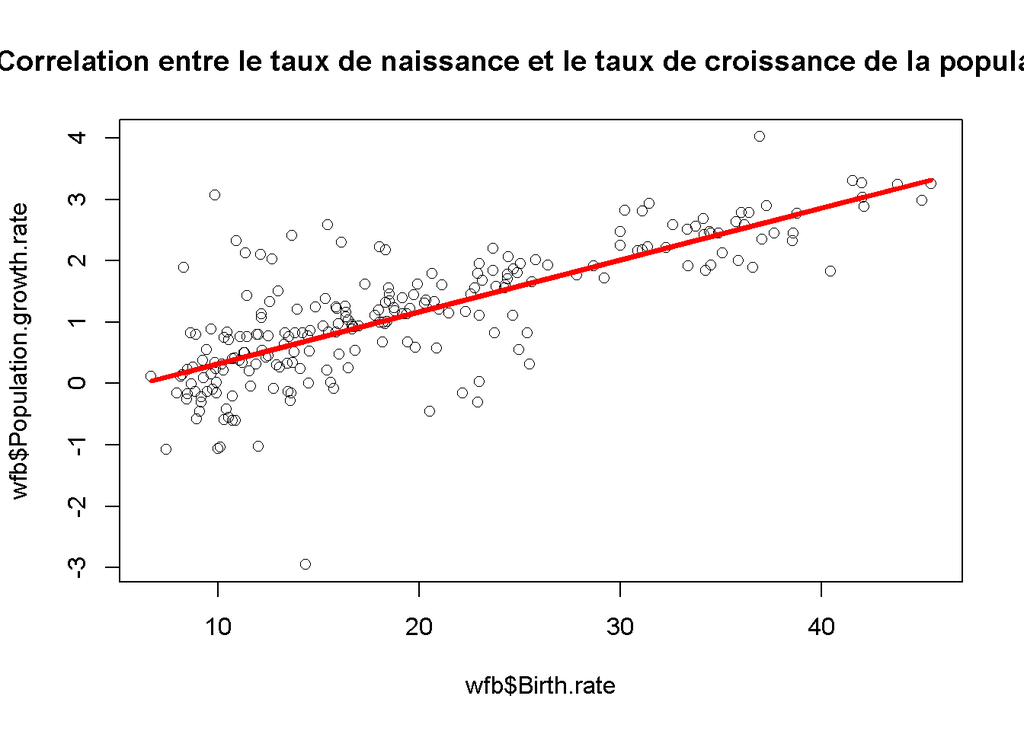

```r
#Equation de la droite
y = a*xi+b

#Graphe
leg=paste("y =",round(a,3),"x +",round(b,3))
lines(y~wfb_restreint2$Birth.rate, type='l',col='red', lwd=3)
legend(10,100,leg,col='red', lty=1:2,cex = 0.8)
```

```r
#Calcul du coefficient lineaire
RSS=sum((yi-y)^2)
TSS=sum((yi-ybar)^2)

coeff = 1-(RSS/TSS)
coeff
```

```
## [1] 0.5850386
```

### Vérification avec R

```r
model<-lm(Population.growth.rate ~ Birth.rate , data = wfb)
summary(model)
```

```
##
## Call:
## lm(formula = Population.growth.rate ~ Birth.rate, data = wfb)
##
## Residuals:
##     Min      1Q  Median      3Q     Max
## -3.6413 -0.3130  0.0424  0.2945  2.7582
##
## Coefficients:
##              Estimate Std. Error t value Pr(>|t|)
## (Intercept) -0.519793   0.103311  -5.031    1e-06 ***
## Birth.rate   0.084516   0.004777  17.692   <2e-16 ***
## ---
## Signif. codes:  0 '***' 0.001 '**' 0.01 '*' 0.05 '.' 0.1 ' ' 1
##
## Residual standard error: 0.6782 on 222 degrees of freedom
##   (55 observations deleted due to missingness)
## Multiple R-squared:  0.585,  Adjusted R-squared:  0.5832
## F-statistic:   313 on 1 and 222 DF,  p-value: < 2.2e-16
```

a, b et le coefficient linéaire sont corrects

### intervalle de confiance

```r
modelpred <- predict(model,wfb_restreint2 , interval="prediction")
intervallemin=modelpred[2]
intervallemax=modelpred[3]
?p
```

```
## starting httpd help server ... done
```

```r
intervallemin
```

```
## [1] 0.5721563
```

```r
intervallemax
```

```
## [1] 1.480705
```

```r
erreur=(intervallemax-intervallemin)/2
erreur
```

```
## [1] 0.4542744
```

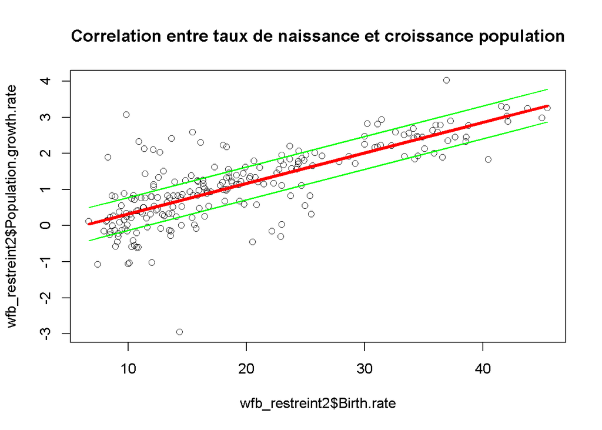

```r
plot(wfb_restreint2$Birth.rate, wfb_restreint2$Population.growth.rate, lwd=0.5, title("Correlation entre taux de naissance et croissance population"))

leg =paste("y =",round(a,3),"x",round(b,3))
lines(y~wfb_restreint2$Birth.rate, type='l',col='red', lwd=3)
z=y+erreur
zz=y-erreur
lines(z~wfb_restreint2$Birth.rate, type='l',col='green', lwd=1)
lines(zz~wfb_restreint2$Birth.rate, type='l',col='green', lwd=1)
legend(10,100,leg,col='red', lty=1:2,cex = 0.8)
```

### Conclusion

Nous obtenons un coefficient linéaire d’environ 0.59. Comme plus le coefficient se rapproche de 1, plus les variables sont corrélées, ces deux variables semblent être corrélées. Sur le graphe, nous observons la pente de l’équation de la droite positive : plus il y a de naissance, plus le taux de la popolation augmente.